# L1000_analysis_using_prot_pair_averages

## Loading data

Load in the L1000_prot_pair_averages.rdata file from github

This is the data created in the L1000_protein_pairs_creating_averages.R script

We have multiplied the shRNA z-scores by -1

The shRNA is a loss of function perturbagen, the cDNA peturbagen over expresses wild type genes, therefore to make them comparable we multiple the shRNA z-scores by -1

```r
githubURL <- "https://github.com/hw15842/L1000_protein_pair_trait_MR/blob/master/Data/L1000_prot_pair_averages.rdata?raw=true"
load(url(githubURL))
head(L1000_prot_pair_averages, n=2)
```

```
##   prot_1 prot_2 num_tests        min         Q1     median        mean
## 1 MAP2K4   A1CF        13 -0.6942676 -0.3076713 -0.1828939  0.05553919
## 2 LRPPRC   A1CF        10 -1.0959874 -0.5788126 -0.2520973 -0.25232022
##          Q3       max
## 1 0.4066875 0.7944757
## 2 0.2394815 0.4173163
```

## Investigating the dataset

What are some features of this data

```r
summary(L1000_prot_pair_averages$mean)
```

```
##      Min.   1st Qu.    Median      Mean   3rd Qu.      Max.
## -4.968921 -0.152163  0.003151  0.007474  0.161832  6.468328
```

## Extracting significant z-scores

We use the pnorm() func to turn the z-scores into p-values

We determine if it is a significant p-value by dividing 0.05 by 401,080 - this is the number of original protein pairs before adding "forward and reverse" prot pairs

```r
L1000_prot_pair_averages$pval_mean_z <- (pnorm(abs(L1000_prot_pair_averages$mean), lower.tail=F))*2
L1000_prot_pair_averages$sig_zscore_mean <- ifelse(L1000_prot_pair_averages$pval_mean_z < (0.05/401080), "Yes", "No")

table(L1000_prot_pair_averages$sig_zscore_mean)
```

```
##
##     No    Yes
## 194507      1
```

```r
# Only 1 of the protein pairs have a significant z-score at this threshold

# Just look at 0.05 threshold

L1000_prot_pair_averages$sig_zscore_mean <- ifelse(L1000_prot_pair_averages$pval_mean_z < 0.05, "Yes", "No")

table(L1000_prot_pair_averages$sig_zscore_mean)
```

```
##
##     No    Yes
## 194426     82
```

So there are only 82 protein pairs that are significant at the very high threshold of 0.05

## Looking at maximum rather than average

Rather than using the average of the z-scores, we will look at the largest value. The different z-scores come from the different cell lines in which the analysis took place

We need to determine the **absolute** largest Z-score (i.e. the "largest" negative number or largest positive number)

We can also do FDR correction for multiple testing which is slightly less stringent

```r
L1000_prot_pair_averages$sig_zscore_mean <- NULL

L1000_prot_pair_averages$largest <- ifelse(abs(L1000_prot_pair_averages$min) > abs(L1000_prot_pair_averages$max), L1000_prot_pair_averages$min, L1000_prot_pair_averages$max)

L1000_prot_pair_averages$pval_max_z <- (pnorm(abs(L1000_prot_pair_averages$largest), lower.tail=F))*2

L1000_prot_pair_averages$fdr <- p.adjust(L1000_prot_pair_averages$pval_max_z, "fdr")

table(L1000_prot_pair_averages$fdr < 0.05)
```

```
##
##  FALSE   TRUE
## 189400   5108
```

This now gives us 194,508 protein pairs that are in the L1000 data with 5,108 protein pairs that pass multiple testing threshold.

# Comparing L1000 to protein pair MR

We are going to look at multiple ways of comparing the L1000 protein pairs to our MR results for the protein pairs

# Can MR predict the directionality of the causal relationship between two proteins?

We are going to look at this in two ways:

1. Getting the R-squared values and performing stieger filtering to determine directionality then comparing to L1000 direction and FDR values for significance
2. Look at the subset of L1000 data that has fwd and rev prot pairs and compare that to the R-squared values
3. Looking at the beta values to determine directionality

and then we will compare both of these to the directionality as dictated by the L1000 dataset

## Get the R<sup>2</sup> values

We need to get the R<sup>2</sup> values for the SNP on the exposure and the SNP on the outcome for all the protein pairs

If the SNP-exposure has the larger R<sup>2</sup> , it might suggest that the exposure influences the outcome and vice versa.

We can also use stieger filtering to determine if one R<sup>2</sup> is significantly larger than the other.

We calculated the R<sup>2</sup> values using the Calculating_R_squared_prot_pairs.R script which ran the data iteratively to stop it timing out We combined the R<sup>2</sup> tables from the iterative analysis in the combining_rsq_data.R script

read in the rsq data table - this is too large to be uploaded via git so have just downloaded it via filezila to my computer

```r
load("/Users/hw15842/Documents/PhD_work/Chapter4_L1000_MR_triplicates_analyses/L1000_protein_pair_trait_MR/Data/rsq_dat.rdata")
head(rsq_dat, n=3)
```

```
##          SNP effect_allele.exposure other_allele.exposure effect_allele.outcome
## 1 rs11667946                      T                     C                     T
## 2 rs33988101                      T                     G                     T
## 3 rs33988101                      T                     G                     T
##   other_allele.outcome beta.exposure beta.outcome eaf.exposure eaf.outcome
## 1                    C       -0.2984       0.1368       0.4730     0.54706
## 2                    G        0.1401       0.1116       0.4811     0.48110
## 3                    G        0.1401       0.1116       0.4811     0.48110
##   remove palindromic ambiguous  id.outcome chr      pos se.outcome
## 1  FALSE       FALSE     FALSE prot-a-1666  19 51474241     0.0264
## 2  FALSE       FALSE     FALSE   prot-b-48  19 49218111     0.0238
## 3  FALSE       FALSE     FALSE   prot-b-48  19 49218111     0.0238
##   samplesize.outcome pval.outcome                                    outcome
## 1               3301  2.18776e-07             Kallikrein-7 || id:prot-a-1666
## 2               3394  2.72402e-06 matrix metallopeptidase 10 || id:prot-b-48
```

[output cut: 29 more lines]

```r
nrow(rsq_dat)
```

```
## [1] 458002
```

```r
nrow(unique(rsq_dat))
```

```
## [1] 380977
```

```r
## When creating the rsq_dat file, some of the outcome proteins were in the dataset twice because of there being two seperate pQTLs for them
## We don't need the pQTLs, it just means some have been run twice, so we can now just keep the unique rows

rsq_dat <- unique(rsq_dat)
```

## 1) Does the direction of the R<sup>2</sup> correlate with the direction of the Z-score?

Does the direction of the R<sup>2</sup> match the direction as predicted by the L1000 data for the protein pairs

**Re-cap**

R<sup>2</sup>

- We have an R<sup>2</sup> for the exposure and outcome protein in the rsq_dat table
- the largest R<sup>2</sup> for the exposure or outcome is the protein that goes "first"
- steiger filtering can benuse to determine if there is a significant difference between the two R<sup>2</sup> values

L1000

- the "largest" column is the largest number in either "max" or "min" collumne
- i.e. the largest absolute Z-score, but has kept the sign (-/+)
- the direction is prot 1 on prot 2 as that is what we extracted from the L1000 dataset
- we also did the reverse so if the reverse was in the dataset it is also in there

```r
## keep just the steiger columns from rsq_dat

rsq_dat_steiger_info <- subset(rsq_dat, select=c(id.exposure, id.outcome, SNP, rsq.exposure, rsq.outcome, steiger_dir, steiger_pval))
table(rsq_dat_steiger_info$steiger_dir)
```

```
##
##  FALSE   TRUE
##  88612 292365
```

```r
load("/Users/hw15842/Documents/PhD_work/protein_interactions/Data/protein_linker_file.rdata")
head(protein_linker_file, n=2)
```

```
##   protein_number       protein_ID protein_name
## 1    prot-a-1000 EWSR1.12988.49.3        EWSR1
## 2    prot-a-1001  EXOSC1.7930.3.3       EXOSC1
```

The protein linker file only has the names of the prot-a proteins, this is ok as this was also used to create the "all_real_prot_on_prot" data file which was used to extract the data from the L1000 data base.

```r
num_exp_prot_a <- length(grep("prot-a", rsq_dat_steiger_info$id.exposure))
num_exp_prot_a
```

```
## [1] 378244
```

```r
num_out_prot_a <- length(grep("prot-a", rsq_dat_steiger_info$id.outcome))
num_out_prot_a
```

```
## [1] 380410
```

```r
nrow(rsq_dat_steiger_info) - num_exp_prot_a
```

```
## [1] 2733
```

```r
nrow(rsq_dat_steiger_info) - num_out_prot_a
```

```
## [1] 567
```

so we only loose 2733 expsure proteins and 567 outcome proteins of the total 380,977 protein pairs but just using the prot-a data This data wasnt extracted from the L1000 data set anyway

```r
rsq_dat_steiger_info <- merge(rsq_dat_steiger_info, protein_linker_file, by.x="id.exposure", by.y="protein_number")
names(rsq_dat_steiger_info)[8:9] <- c("Exposure_protein_ID","Exposure_protein_name")

rsq_dat_steiger_info <- merge(rsq_dat_steiger_info, protein_linker_file, by.x="id.outcome", by.y="protein_number")
names(rsq_dat_steiger_info)[10:11] <- c("Outcome_prtein_ID","Outcome_protein_name")

rsq_dat_steiger_info <- rsq_dat_steiger_info[c(2,1,3:11)]  ## put the exposure column first

head(rsq_dat_steiger_info, n=2)
```

```
##   id.exposure id.outcome       SNP rsq.exposure rsq.outcome steiger_dir
## 1 prot-a-1842   prot-a-1 rs2228243    0.2419547  0.01315152        TRUE
## 2 prot-a-2184   prot-a-1 rs2304456    0.2404097  0.04714217        TRUE
##   steiger_pval Exposure_protein_ID Exposure_protein_name Outcome_prtein_ID
## 1 3.056620e-66    MAP2K4.5242.37.3                MAP2K4   A1CF.12423.38.3
## 2 1.177585e-37   PARP16.7881.244.3                PARP16   A1CF.12423.38.3
##   Outcome_protein_name
## 1                 A1CF
## 2                 A1CF
```

```r
head(L1000_prot_pair_averages, n=2)
```

```
##   prot_1 prot_2 num_tests        min         Q1     median        mean
## 1 MAP2K4   A1CF        13 -0.6942676 -0.3076713 -0.1828939  0.05553919
## 2 LRPPRC   A1CF        10 -1.0959874 -0.5788126 -0.2520973 -0.25232022
##          Q3       max pval_mean_z    largest pval_max_z       fdr
## 1 0.4066875 0.7944757   0.9557089  0.7944757  0.4269186 0.5386202
## 2 0.2394815 0.4173163   0.8007936 -1.0959874  0.2730843 0.4942613
```

For the R<sup>2</sup> data, the "steiger_dir" column tells us whether the R-squared value is larger for the exposure (TRUE) or the outcome (FALSE).

In the L1000 data we have the fdr adjusted pvalue to tell us if protein 1 significantly influences protein 2

```r
## Convert the rsq data to be the "correct" direction based in the steiger_dir column

rsq_dat_steiger_info$prot_1 <- ifelse(rsq_dat_steiger_info$steiger_dir == "TRUE", paste0(rsq_dat_steiger_info$Exposure_protein_name), paste0(rsq_dat_steiger_info$Outcome_protein_name))
rsq_dat_steiger_info$prot_2 <- ifelse(rsq_dat_steiger_info$steiger_dir == "TRUE", paste0(rsq_dat_steiger_info$Outcome_protein_name), paste0(rsq_dat_steiger_info$Exposure_protein_name))

head(rsq_dat_steiger_info, n=2)
```

```
##   id.exposure id.outcome       SNP rsq.exposure rsq.outcome steiger_dir
## 1 prot-a-1842   prot-a-1 rs2228243    0.2419547  0.01315152        TRUE
## 2 prot-a-2184   prot-a-1 rs2304456    0.2404097  0.04714217        TRUE
##   steiger_pval Exposure_protein_ID Exposure_protein_name Outcome_prtein_ID
## 1 3.056620e-66    MAP2K4.5242.37.3                MAP2K4   A1CF.12423.38.3
## 2 1.177585e-37   PARP16.7881.244.3                PARP16   A1CF.12423.38.3
##   Outcome_protein_name prot_1 prot_2
## 1                 A1CF MAP2K4   A1CF
## 2                 A1CF PARP16   A1CF
```

```r
head(L1000_prot_pair_averages, n=2)
```

```
##   prot_1 prot_2 num_tests        min         Q1     median        mean
## 1 MAP2K4   A1CF        13 -0.6942676 -0.3076713 -0.1828939  0.05553919
## 2 LRPPRC   A1CF        10 -1.0959874 -0.5788126 -0.2520973 -0.25232022
##          Q3       max pval_mean_z    largest pval_max_z       fdr
## 1 0.4066875 0.7944757   0.9557089  0.7944757  0.4269186 0.5386202
## 2 0.2394815 0.4173163   0.8007936 -1.0959874  0.2730843 0.4942613
```

```r
L1000_prot_pair_averages$prot_1 <- as.character(L1000_prot_pair_averages$prot_1)
L1000_prot_pair_averages$prot_2 <- as.character(L1000_prot_pair_averages$prot_2)

rsq_dat_in_L1000 <- subset(rsq_dat_steiger_info, rsq_dat_steiger_info$prot_1 %in% L1000_prot_pair_averages$prot_1 & rsq_dat_steiger_info$prot_2 %in% L1000_prot_pair_averages$prot_2)

head(rsq_dat_in_L1000, n=2)
```

```
##   id.exposure id.outcome       SNP rsq.exposure rsq.outcome steiger_dir
## 1 prot-a-1842   prot-a-1 rs2228243    0.2419547  0.01315152        TRUE
## 5 prot-a-1783   prot-a-1 rs2228243    0.2036761  0.01315152        TRUE
##   steiger_pval Exposure_protein_ID Exposure_protein_name Outcome_prtein_ID
## 1 3.056620e-66    MAP2K4.5242.37.3                MAP2K4   A1CF.12423.38.3
## 5 2.488098e-51    LRPPRC.9046.46.3                LRPPRC   A1CF.12423.38.3
##   Outcome_protein_name prot_1 prot_2
## 1                 A1CF MAP2K4   A1CF
## 5                 A1CF LRPPRC   A1CF
```

```r
nrow(rsq_dat_in_L1000)
```

```
## [1] 127872
```

We now want to compare the strength of the associations in the rsq data and the L1000 data so put them all into one table

```r
rsq_dat_in_L1000$prot1_on_prot2 <- paste0(rsq_dat_in_L1000$prot_1, "_on_", rsq_dat_in_L1000$prot_2)
L1000_prot_pair_averages$prot1_on_prot2 <- paste0(L1000_prot_pair_averages$prot_1, "_on_", L1000_prot_pair_averages$prot_2)

rsq_and_L1000_dat <- merge(L1000_prot_pair_averages, rsq_dat_in_L1000, by="prot1_on_prot2")
head(rsq_and_L1000_dat, n=2)
```

```
##   prot1_on_prot2 prot_1.x prot_2.x num_tests        min          Q1     median
## 1 AARS_on_ACVR1B     AARS   ACVR1B        13 -0.9134892 -0.08821168  0.1346659
## 2 AARS_on_ADAM12     AARS   ADAM12        13 -0.8892565 -0.24019563 -0.1996777
##          mean        Q3       max pval_mean_z    largest pval_max_z       fdr
## 1  0.04953292 0.2730693 0.8747044   0.9604946 -0.9134892  0.3609853 0.5108092
## 2 -0.14565258 0.1224114 0.4323345   0.8841957 -0.8892565  0.3738653 0.5150816
##   id.exposure id.outcome        SNP rsq.exposure rsq.outcome steiger_dir
## 1    prot-a-3  prot-a-22 rs62143197   0.01405501 0.012477577        TRUE
## 2    prot-a-3  prot-a-26 rs62143197   0.01405501 0.007575101        TRUE
##   steiger_pval Exposure_protein_ID Exposure_protein_name Outcome_prtein_ID
## 1    0.7779958     AARS.12340.17.3                  AARS  ACVR1B.2806.49.2
## 2    0.1957720     AARS.12340.17.3                  AARS   ADAM12.4420.7.2
##   Outcome_protein_name prot_1.y prot_2.y
## 1               ACVR1B     AARS   ACVR1B
## 2               ADAM12     AARS   ADAM12
```

Now we want to see if the significant steiger pvalue results have a stronger fdr value in the L1000 data So we can do a T-test to compare the means of the FDR values between the two groupe (sig steiger pval vs non sig steiger pval)

```r
sig_steiger_pval <- subset(rsq_and_L1000_dat, rsq_and_L1000_dat$steiger_pval < 0.05)
non_sig_steiger_pval <- subset(rsq_and_L1000_dat, rsq_and_L1000_dat$steiger_pval > 0.05)

t.test(sig_steiger_pval$fdr, non_sig_steiger_pval$fdr)
```

```
##
##  Welch Two Sample t-test
##
## data:  sig_steiger_pval$fdr and non_sig_steiger_pval$fdr
## t = -3.8794, df = 49875, p-value = 0.0001048
## alternative hypothesis: true difference in means is not equal to 0
## 95 percent confidence interval:
##  -0.005636033 -0.001852551
## sample estimates:
## mean of x mean of y
## 0.4972615 0.5010058
```

So there is a small significant difference between the means of the two groups, however the 95% confidence intervals are quite small

Does a significant steiger pvalue mean more likely to be a significant fdr value?

```r
(prop.table(table(sig_steiger_pval$fdr<0.05)))*100
```

```
##
##    FALSE     TRUE
## 97.05813  2.94187
```

```r
(prop.table(table(non_sig_steiger_pval$fdr<0.05)))*100
```

```
##
##     FALSE      TRUE
## 97.412918  2.587082
```

Both just under 3% of the fdr values are signifcant in both the sig and non sig stieger pvalue groups

So it appears as though having a significant stieger p-value does not seem to have much of an influence on whether the L1000 fdr value is significant

## 2) Does the R-squared data predict the same direction when looking at protein pairs that have fwd and rev data in L1000

For the L1000 data that has data for protein 1 on protein 2 and for the reverse direction, which direction has the largest fdr value and does the R-squared data predict the same direction?

To assess this we will perform a binomial test

- Number of trials = number of L1000 protein pairs that have a fwd and rev
- Probability of success = 0.5 (i.e. 50%)
- Number of times correct = number of times that the steiger direction same as the L1000 direction

```r
L1000_fwd_and_rev_pairs <- subset(L1000_prot_pair_averages, L1000_prot_pair_averages$prot_1 %in% L1000_prot_pair_averages$prot_2 & L1000_prot_pair_averages$prot_2 %in% L1000_prot_pair_averages$prot_1)

## Check does the right thing
L1000_fwd_and_rev_pairs_check <- L1000_prot_pair_averages
L1000_fwd_and_rev_pairs_check$prot2_on_prot1 <- paste0(L1000_fwd_and_rev_pairs_check$prot_2, "_on_", L1000_fwd_and_rev_pairs_check$prot_1)
L1000_fwd_and_rev_pairs_check <- subset(L1000_fwd_and_rev_pairs_check, L1000_fwd_and_rev_pairs_check$prot1_on_prot2 %in% L1000_fwd_and_rev_pairs_check$prot2_on_prot1)

nrow(L1000_fwd_and_rev_pairs)
```

```
## [1] 86594
```

```r
nrow(L1000_fwd_and_rev_pairs_check)
```

```
## [1] 86594
```

```r
## Same num rows so worked

## now to run the binomial test

L1000_fwd_and_rev_pairs_rsq_dat <- merge(L1000_fwd_and_rev_pairs, rsq_dat_in_L1000, by="prot1_on_prot2")

binom.test(x=nrow(subset(L1000_fwd_and_rev_pairs_rsq_dat, L1000_fwd_and_rev_pairs_rsq_dat$steiger_pval < 0.05)), n=nrow(L1000_fwd_and_rev_pairs_rsq_dat), p=0.5)
```

```
##
##  Exact binomial test
##
## data:  nrow(subset(L1000_fwd_and_rev_pairs_rsq_dat, L1000_fwd_and_rev_pairs_rsq_dat$steiger_pval <  and nrow(L1000_fwd_and_rev_pairs_rsq_dat)    0.05)) and nrow(L1000_fwd_and_rev_pairs_rsq_dat)
## number of successes = 43226, number of trials = 56171, p-value <
## 2.2e-16
## alternative hypothesis: true probability of success is not equal to 0.5
## 95 percent confidence interval:
##  0.7660376 0.7730205
## sample estimates:
## probability of success
##               0.769543
```

## 3) Does the *Beta* correlate with the Z-score

We have the *beta* values for the MR of the protein pairs

# Can MR predict the association of two proteins? (not looking at directionality)

We want to determine if a significant MR result can determine if the protein pair is significant in the L1000 data

## does the L1000 hep us to determine if we shold be Removing the mass pleiotropy pQTls

We need to consider and then remove the protein interactions that are due to a mass pleiotropy pQTL as we have determined that these interactions are likely due to biases in the data rather than true biological associations.

We will then also need to change the multiple testing to adjust for this removal of protein pairs

However I also want to just do some analysis to evaluate if the L1000 data picks up the mass pleiotropy protein pairs, if not adds further credibility to our theory that they are not true biological associations.

For this section we will use data that has been created above, then after we have removed the mass pleiotropy pQTL associations we will re-run the above analysis in a different order that makes more sense for the flow of the paper

```r
mass_pleio_snps <- read.table("/Users/hw15842/Documents/PhD_work/protein_interactions/new_results/mass_pleio_snps.txt")

rsq_L1000_mass_pleio_assocs <- subset(rsq_and_L1000_dat, rsq_and_L1000_dat$SNP %in% mass_pleio_snps$V1)

rsq_L1000_non_mass_pleio_assocs <- subset(rsq_and_L1000_dat, !rsq_and_L1000_dat$SNP %in% mass_pleio_snps$V1)

(prop.table(table(rsq_L1000_mass_pleio_assocs$fdr<0.05)))*100
```

```
##
##     FALSE      TRUE
## 97.137584  2.862416
```

```r
(prop.table(table(rsq_L1000_non_mass_pleio_assocs$fdr<0.05)))*100
```

```
##
##     FALSE      TRUE
## 97.410777  2.589223
```

So the percentages of fdr values less than 0.05 are basically exactly the same in the mass pleiotopy and non-mass pleiotropy subsets of the protein pairs

Doesnt really support our theory that the mass pleio associations are less likely to be biological..... May need to think about this again but for now going to continue with the analysis by removing the mass pleiotropy pQTL associations

# Removing all of the previous data and re starting with no mass pleio snps and running in more coherent order

```r
rm(list = ls())

ls()
```

```
## character(0)
```

/

//

///

////

/////

/////

/////

////

///

//

/

# Starting again - no mass pleio pQTLs

## Three questions to answer

1. Can the MR results predict the same protein pairs as the L1000 data
2. Can the MR results predict the same protein orientation as the L1000 data
3. Can the MR results predict the same direction of effect as the L1000 data

First we need to get the data and remove the mass pleio pQTLs (doing this again as may remove the data from above)

```r
# Load in the L1000 results
githubURL <- "https://github.com/hw15842/L1000_protein_pair_trait_MR/blob/master/Data/L1000_prot_pair_averages.rdata?raw=true"
load(url(githubURL))

# determine absolute largest z-score, create a pval and fdr corrected pval for it
L1000_prot_pair_averages$largest <- ifelse(abs(L1000_prot_pair_averages$min) > abs(L1000_prot_pair_averages$max), L1000_prot_pair_averages$min, L1000_prot_pair_averages$max)
L1000_prot_pair_averages$pval_max_z <- (pnorm(abs(L1000_prot_pair_averages$largest), lower.tail=F))*2
L1000_prot_pair_averages$fdr <- p.adjust(L1000_prot_pair_averages$pval_max_z, "fdr")

# load in the rsq_dat
load("/Users/hw15842/Documents/PhD_work/Chapter4_L1000_MR_triplicates_analyses/L1000_protein_pair_trait_MR/Data/rsq_dat.rdata")
## When creating the rsq_dat file, some of the outcome proteins were in the dataset twice because of there being two seperate pQTLs for them
## We don't need the pQTLs, it just means some have been run twice, so we can now just keep the unique rows
rsq_dat <- unique(rsq_dat)

# load in the mass pleiotropy pQTL file
mass_pleio_snps <- read.table("/Users/hw15842/Documents/PhD_work/protein_interactions/new_results/mass_pleio_snps.txt")


# remove the mass pleiotropy pQTLs from the rsq_dat file
rsq_dat <- subset(rsq_dat, ! rsq_dat$SNP %in% mass_pleio_snps$V1)


# create data frame with jsut the steiger info
rsq_dat_steiger_info <- subset(rsq_dat, select=c(id.exposure, id.outcome, SNP, rsq.exposure, rsq.outcome, steiger_dir, steiger_pval, beta.exposure, beta.outcome, se.exposure, se.outcome))

# load in the protein linker file for the prot-a protein names
load("/Users/hw15842/Documents/PhD_work/protein_interactions/Data/protein_linker_file.rdata")

# Add the protein names to the rsq steiger nmp data frame

rsq_dat_steiger_info <- merge(rsq_dat_steiger_info, protein_linker_file, by.x="id.exposure", by.y="protein_number")
names(rsq_dat_steiger_info)[12:13] <- c("Exposure_protein_ID","Exposure_protein_name")

rsq_dat_steiger_info <- merge(rsq_dat_steiger_info, protein_linker_file, by.x="id.outcome", by.y="protein_number")
names(rsq_dat_steiger_info)[14:15] <- c("Outcome_protein_ID","Outcome_protein_name")

rsq_dat_steiger_info <- rsq_dat_steiger_info[c(2,1,3:15)]  ## put the exposure column first


# We now have the rsq data with the mass pleio pQTLs removed
# and the L1000 data with the pvalue and fdrs added (this still contains protein pairs that may be due to mass pleio pQTLs at the moment, will remove when we merge with rsq data next)
```

## 2) Can the MR results predict the same protein orientation as the L1000 data

We will assess this in two ways

- Does a smaller steiger pvalue correlate with a smaller FDR value
- Does the R<sup>2</sup> orientation match the L1000 orientation (for the L1000 data that has data about both protein orientations)

#### Does a smaller steiger pvalue correlate with a smaller FDR value

```r
## Convert the rsq data to be the "correct" direction based in the steiger_dir column

rsq_dat_steiger_info$prot_1 <- ifelse(rsq_dat_steiger_info$steiger_dir == "TRUE", paste0(rsq_dat_steiger_info$Exposure_protein_name), paste0(rsq_dat_steiger_info$Outcome_protein_name))
rsq_dat_steiger_info$prot_2 <- ifelse(rsq_dat_steiger_info$steiger_dir == "TRUE", paste0(rsq_dat_steiger_info$Outcome_protein_name), paste0(rsq_dat_steiger_info$Exposure_protein_name))

## Also add in the beta values for the new orientation as well

rsq_dat_steiger_info$prot_1_beta <- ifelse(rsq_dat_steiger_info$steiger_dir == "TRUE", paste0(rsq_dat_steiger_info$beta.exposure), paste0(rsq_dat_steiger_info$beta.outcome))
rsq_dat_steiger_info$prot_2_beta <- ifelse(rsq_dat_steiger_info$steiger_dir == "TRUE", paste0(rsq_dat_steiger_info$beta.outcome), paste0(rsq_dat_steiger_info$beta.exposure))

# Make the L1000 prot columns into charactor vectors

L1000_prot_pair_averages$prot_1 <- as.character(L1000_prot_pair_averages$prot_1)
L1000_prot_pair_averages$prot_2 <- as.character(L1000_prot_pair_averages$prot_2)

# Combine the two data frames - there are no mass pleio prot pairs in the rsq data so this next step wont have them in either

rsq_dat_steiger_info$prot1_on_prot2 <- paste0(rsq_dat_steiger_info$prot_1, "_on_", rsq_dat_steiger_info$prot_2)
L1000_prot_pair_averages$prot1_on_prot2 <- paste0(L1000_prot_pair_averages$prot_1, "_on_", L1000_prot_pair_averages$prot_2)

rsq_and_L1000_dat <- merge(L1000_prot_pair_averages, rsq_dat_steiger_info, by="prot1_on_prot2")


## Re-calculate a new FDR corrected pvalue for this data as we have now removed the mass pleio pairs

rsq_and_L1000_dat$fdr_new <- p.adjust(rsq_and_L1000_dat$pval_max_z, "fdr")


# split into sig and non-sig steiger pvals and see if sig difference in the new fdr values between the two groups
sig_steiger_pval <- subset(rsq_and_L1000_dat, rsq_and_L1000_dat$steiger_pval < 0.05)
non_sig_steiger_pval <- subset(rsq_and_L1000_dat, rsq_and_L1000_dat$steiger_pval > 0.05)

t.test(sig_steiger_pval$fdr_new, non_sig_steiger_pval$fdr_new)
```

```
##
##  Welch Two Sample t-test
##
## data:  sig_steiger_pval$fdr_new and non_sig_steiger_pval$fdr_new
## t = -1.0718, df = 896.26, p-value = 0.2841
## alternative hypothesis: true difference in means is not equal to 0
## 95 percent confidence interval:
##  -0.021082911  0.006189346
## sample estimates:
## mean of x mean of y
## 0.4659104 0.4733571
```

So there is a no significant difference between the two groups

Have a look at the percentages and create an odds ratio for this data

Odds ratio: a is the number of times both A and B are present, b is the number of times A is present, but B is absent, c is the number of times A is absent, but B is present, and d is the number of times both A and B are negative.

```r
# percentages of the sig and nonsig steiger pvals that have a significant FDR with the new fdr value
(prop.table(table(sig_steiger_pval$fdr_new<0.05)))*100
```

```
##
##     FALSE      TRUE
## 97.805643  2.194357
```

```r
(prop.table(table(non_sig_steiger_pval$fdr_new<0.05)))*100
```

```
##
##     FALSE      TRUE
## 96.822034  3.177966
```

```r
# Calculate the odds ratio
library(epitools)

a <- as.numeric(table(sig_steiger_pval$fdr_new<0.05)[2]) # sig steiger and sig FDR
b <- as.numeric(table(sig_steiger_pval$fdr_new<0.05)[1]) # sig steiger and non-sig FDR
c <- as.numeric(table(non_sig_steiger_pval$fdr_new<0.05)[2]) # non-sig steiger and sig FDR
d <- as.numeric(table(non_sig_steiger_pval$fdr_new<0.05)[1]) # non-sig steiger and non-sig FDR


odds_ratio <- (a*d)/(b*c)
odds_ratio
```

```
## [1] 0.683547
```

```r
oddsratio.wald(matrix(c(a,b,c,d),nrow = 2, ncol = 2))
```

```
## $data
##           Outcome
## Predictor  Disease1 Disease2 Total
##   Exposed1       21       15    36
##   Exposed2      936      457  1393
##   Total         957      472  1429
##
## $measure
##           odds ratio with 95% C.I.
## Predictor  estimate     lower    upper
##   Exposed1 1.000000        NA       NA
##   Exposed2 0.683547 0.3490911 1.338437
##
## $p.value
##           two-sided
## Predictor  midp.exact fisher.exact chi.square
##   Exposed1         NA           NA         NA
##   Exposed2  0.2731754     0.283396  0.2644502
##
## $correction
## [1] FALSE
##
## attr(,"method")
## [1] "Unconditional MLE & normal approximation (Wald) CI"
```

So the odds ratio is 0.68 with a 95% CI of 0.35 to 1.33

#### Does the R<sup>2</sup> orientation match the L1000 orientation

For the L1000 data that has data for protein 1 on protein 2 and for the reverse orientation, which orientation has the smallest fdr value and does the R-squared data predict the same direction?

To assess this we will perform a binomial test

- Number of trials = number of L1000 protein pairs that have a fwd and rev
- Probability of success = 0.5 (i.e. 50%)
- Number of times correct = number of times that the steiger direction same as the L1000 direction

```r
# Remove the duplicated p1 on p2 rows
# we have some protein names that are the same for different protein numbers
p1_same_p2 <- subset(rsq_dat_steiger_info, rsq_dat_steiger_info$prot_1 == rsq_dat_steiger_info$prot_2)
nrow(p1_same_p2)
```

```
## [1] 45
```

```r
library(ieugwasr)
p1_same_p2_gwasinfo_exp <- gwasinfo(p1_same_p2$id.exposure)
p1_same_p2_gwasinfo_out <- gwasinfo(p1_same_p2$id.outcome)
p1_same_p2_gwasinfo_both <- cbind(p1_same_p2_gwasinfo_exp[,1:2], p1_same_p2_gwasinfo_out[,1:2])
names(p1_same_p2_gwasinfo_both) <- c("id.exp", "trait.exp", "id.out", "trait.out")
p1_same_p2_gwasinfo_both$same_trait_name <- ifelse(p1_same_p2_gwasinfo_both$trait.exp == p1_same_p2_gwasinfo_both$trait.out, "YES", "NO")
table(p1_same_p2_gwasinfo_both$same_trait_name)
```

```
##
##  NO YES
##   4  41
```

```r
# So majority of them have the same actual trait name even though they are slightly different GWAS and the ones that vary are only very slightly different
# "Coagulation Factor X" vs "Coagulation factor Xa"
# "Vascular endothelial growth factor A, isoform 121" vs "Vascular endothelial growth factor A"
# "Ck-beta-8-1" vs "C-C motif chemokine 23" - this one is more different  but looking at gene cards https://www.genecards.org/cgi-bin/carddisp.pl?gene=CCL23 they are aliases


# remove the one with the

# create two datasets - one with the correct (forward) orientaion (based on the rsq values) and one with the reverse orientation

fwd_rsq_df <- rsq_dat_steiger_info[!duplicated(rsq_dat_steiger_info[,c("prot1_on_prot2")]),]

rev_rsq_df <- fwd_rsq_df
rev_rsq_df$prot2_on_prot1 <- paste0(rev_rsq_df$prot_2, "_on_", rev_rsq_df$prot_1)
rev_rsq_df$prot1_on_prot2 <- NULL

fwd_rsq_df$alphabet_direction <- ifelse( fwd_rsq_df$prot_1 < fwd_rsq_df$prot_2, paste0(fwd_rsq_df$prot_1 ,"_on_", fwd_rsq_df$prot_2), paste0(fwd_rsq_df$prot_2 ,"_on_", fwd_rsq_df$prot_1))

rev_rsq_df$alphabet_direction <- ifelse( rev_rsq_df$prot_1 < rev_rsq_df$prot_2, paste0(rev_rsq_df$prot_1 ,"_on_", rev_rsq_df$prot_2), paste0(rev_rsq_df$prot_2 ,"_on_", rev_rsq_df$prot_1))


# Add in the L1000 data based on the fwd and rev orientations

fwd_rsq_df <- merge(fwd_rsq_df, L1000_prot_pair_averages, by="prot1_on_prot2")
rev_rsq_df <- merge(rev_rsq_df, L1000_prot_pair_averages, by.x="prot2_on_prot1", by.y = "prot1_on_prot2")

# Just keep the columns we need
fwd_rsq_df <- subset(fwd_rsq_df, select=c(alphabet_direction, prot1_on_prot2, steiger_pval, fdr))
rev_rsq_df <- subset(rev_rsq_df, select=c(alphabet_direction, prot2_on_prot1, steiger_pval, fdr))

colnames(fwd_rsq_df)[2:4] <- paste("FWD", colnames(fwd_rsq_df)[2:4], sep = "_")
colnames(rev_rsq_df)[2:4] <- paste("REV", colnames(rev_rsq_df)[2:4], sep = "_")


both_fwd_rev <- merge(fwd_rsq_df, rev_rsq_df, by="alphabet_direction")
both_fwd_rev$fdr_direction <- ifelse(both_fwd_rev$FWD_fdr  < both_fwd_rev$REV_fdr, "FWD", "REV")

## now to run the binomial test

binom.test(x=length(grep("FWD", both_fwd_rev$fdr_direction)), n=nrow(both_fwd_rev), p=0.5)
```

```
##
##  Exact binomial test
##
## data:  length(grep("FWD", both_fwd_rev$fdr_direction)) and nrow(both_fwd_rev)
## number of successes = 166, number of trials = 491, p-value = 6.332e-13
## alternative hypothesis: true probability of success is not equal to 0.5
## 95 percent confidence interval:
##  0.2963088 0.3818262
## sample estimates:
## probability of success
##              0.3380855
```

## 3) Can the MR results predict the same direction of effect as the L1000 data

We have the *beta* values for the MR of the protein pairs - this tells us whether protein 1 up regulates or down regulates protein 2

The Z-scores have a sign which tell us whether protein 1 up reulgates (+) or down regulates (-) protein 2

(we have already accounted for the two different pertubagen types by multiplying the shRNA z-scores by -1)

Does the direction of the *beta* correlate with the direction of the Z-score

Does the magnitude of the *beta* correlate with the magnitude of the Z-score

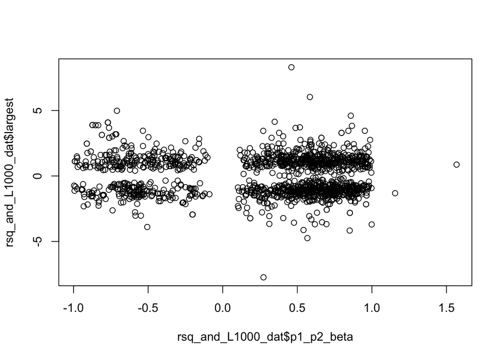

```r
## Calculate the beta of prot 1 on prot 2

rsq_and_L1000_dat$p1_p2_beta <- as.numeric(rsq_and_L1000_dat$prot_2_beta) / as.numeric(rsq_and_L1000_dat$prot_1_beta)

# plot the beta against the z scores to look at the patterns
plot(rsq_and_L1000_dat$p1_p2_beta, rsq_and_L1000_dat$largest)
```

```r
rsq_and_L1000_dat$beta_z_sign_same <- ifelse(sign(rsq_and_L1000_dat$p1_p2_beta) == sign(rsq_and_L1000_dat$largest), "YES", "NO")

prop.table(table(rsq_and_L1000_dat$beta_z_sign_same))*100
```

```
##
##       NO      YES
## 53.81386 46.18614
```

```r
# more of them dont match signs than do but both around 50%
```

# Conclusions

It does not appear as though our MR data match up well with the L1000 data in determining orientation of the portein pairs or direction of effect